# Итоговая

Николай Колеганов

30 10 2021

# Анализ данных по продажам банковских продуктов

## Дан набор датасетов по продажам банковских продуктов (депозиты):

##### bank-full.csv - основной датасет, содержит данные о продажах банковских продуктов (депозитов) клиентам на основе телефонных звонков.

### Атрибутивный состав датасета:

#### age (numeric) - возраст клиента

#### job : (categorical: “admin.”, “unknown”, “unemployed”, “management”, “housemaid”, “entrepreneur”, “student”, “blue-collar”, “self-employed”, “retired”, “technician”, “services”) - род занятий клиента

#### marital : (categorical: “married”, “divorced”, “single”) - семейной положение клиента

#### education (categorical: “unknown”,“secondary”,“primary”,“tertiary”) – образование

#### default: (binary: “yes”,“no”) - наличие кредита с просроченной задолженностью

#### balance: (numeric) - среднемесячный баланс на счетах клиента (в евро)

#### housing: (binary: “yes”,“no”) - наличие ипотеки

#### loan: (binary: “yes”,“no”) - наличие потребительского кредита

#### salary: (binary: “yes”,“no”) - наличие зарплатного проекта в банке у клиента

#### contact: (categorical: “unknown”, “telephone”, “cellular”) - тип коммуникации с клиентом

#### day: (numeric) - порядковый номер дня в месяце, когда была последняя коммуникация

#### month: (categorical: “jan”, “feb”, “mar”, …, “nov”, “dec”) - месяц, когда была последняя коммуникация

#### duration:(numeric) - длительность последней коммуникации в секундах

#### campaign: (numeric, includes last contact) - количество контактов с клиентом в рамках данной рекламной кампании

#### pdays: (numeric, -1 means client was not previously contacted) - число дней с прошлой коммуникации

#### previous: (numeric) - число предыдущих коммуникаций с клиентом

#### poutcome: (categorical: “unknown”, “other”, “failure”, “success”) - результат прошлых маркетинговых кампаний

#### y: (binary: “yes”,“no”) - взял ли клиент депозит по итогу коммуникации (выходная переменная для классификации)

#### deposittype (categorical: “max”, “optimum”, “saving”) - продукт, который выдан клиенту в итоге маркетинговой акции (тип депозита)

#### bank-test.csv - тестовый датасет.

Нужен только в случае, если в дипломной работе решается задача классификации. Имеет структуру, аналогичную датасету bank-full.csv

#### deposits-tariff.csv - датасет, содержащий условия по депозитам, выданным клиентам в результате маркетинговой кампании.

### Атрибутивный состав датасета:

#### deposittype (categorical: “max”, “optimum”, “saving”) - продукт, который выдан клиенту в итоге маркетинговой акции (тип депозита)

#### drate: (numeric) - ставка по депозиту в процентах годовых

#### duration: (numeric) - срок депозита в месяцах

#### minbalance: (numeric) - минимальный первоначальный взнос

#### replenishable: (binary: “yes”,“no”) - возможность пополнения депозита

#### withdrawal: (binary: “yes”,“no”) - возможность частичного снятия.

## Загрузка данных

```r
bank_full <- read.csv("D:/данные/разработка/R/итоговая/Diploma datasets/bank-full.csv", header=TRUE,sep=";")
usloviy <- read.csv("D:/данные/разработка/R/итоговая/Diploma datasets/deposits-tariff.csv",  header=TRUE,sep=";")
test_bank <- read.csv("D:/данные/разработка/R/итоговая/Diploma datasets/bank-test.csv", header=TRUE,sep=";")
```

## Посмотрим названия колонок

```r
colnames(test_bank)
```

```
##  [1] "age"       "job"       "marital"   "education" "default"   "balance"
##  [7] "housing"   "loan"      "salary"    "contact"   "day"       "month"
## [13] "duration"  "campaign"  "pdays"     "previous"  "poutcome"  "y"
```

```r
colnames(usloviy)
```

```
## [1] "deposittype"   "drate"         "duration"      "minbalance"
## [5] "replenishable" "withdrawal"
```

# Очистка данных

## для удобаства очистки переместим в clear_bank данные, чтоб неизменить изначальные данные в проуессе проверки

```r
clear_bank <- bank_full
```

## проверим какие классы содержатьсья в данных

```r
sapply(clear_bank, class)
```

```
##         age         job     marital   education     default     balance
##   "integer" "character" "character" "character" "character"   "integer"
##     housing        loan      salary     contact         day       month
## "character" "character" "character" "character"   "integer" "character"
##    duration    campaign       pdays    previous    poutcome           y
##   "integer"   "integer"   "integer"   "integer" "character" "character"
## deposittype
## "character"
```

```r
sapply(test_bank, class)
```

```
##         age         job     marital   education     default     balance
##   "integer" "character" "character" "character" "character"   "integer"
##     housing        loan      salary     contact         day       month
## "character" "character" "character" "character"   "integer" "character"
##    duration    campaign       pdays    previous    poutcome           y
##   "integer"   "integer"   "integer"   "integer" "character" "character"
```

## проверим на пропуски данные

```r
sum(is.na(clear_bank))
```

```
## [1] 5
```

```r
sum(is.null(clear_bank))
```

```
## [1] 0
```

## как видно есть 5 пропусков, проверим в каком именно столбце они есть

```r
sum(is.na(clear_bank["age"]))
```

```
## [1] 5
```

```r
sum(is.na(clear_bank["job"]))
```

```
## [1] 0
```

```r
sum(is.na(clear_bank["marital"]))
```

```
## [1] 0
```

```r
sum(is.na(clear_bank["education"]))
```

```
## [1] 0
```

```r
sum(is.na(clear_bank["default"]))
```

```
## [1] 0
```

```r
sum(is.na(clear_bank["balance"]))
```

```
## [1] 0
```

```r
sum(is.na(clear_bank["housing"]))
```

```
## [1] 0
```

```r
sum(is.na(clear_bank["loan"]))
```

```
## [1] 0
```

```r
sum(is.na(clear_bank["salary"]))
```

```
## [1] 0
```

```r
sum(is.na(clear_bank["contact"]))
```

```
## [1] 0
```

```r
sum(is.na(clear_bank["day"]))
```

```
## [1] 0
```

```r
sum(is.na(clear_bank["month"]))
```

```
## [1] 0
```

```r
sum(is.na(clear_bank["duration"]))
```

```
## [1] 0
```

```r
sum(is.na(clear_bank["campaign"]))
```

```
## [1] 0
```

```r
sum(is.na(clear_bank["pdays"]))
```

```
## [1] 0
```

```r
sum(is.na(clear_bank["previous"]))
```

```
## [1] 0
```

```r
sum(is.na(clear_bank["poutcome"]))
```

```
## [1] 0
```

```r
sum(is.na(clear_bank["y"]))
```

```
## [1] 0
```

```r
sum(is.na(clear_bank["deposittype"]))
```

```
## [1] 0
```

```r
sum(is.null(clear_bank))
```

```
## [1] 0
```

## как видно пропуски только в age и составляет 5 из 45 211. 5 шт. это меньше 1 %, поэтому можно их просто убарть.

```r
clear_bank <- drop_na(clear_bank)

sum(is.na(clear_bank))
```

```
## [1] 0
```

## Посмотрим на получившиеся данные и посмотрим на описательную статистику используя функцию summary.

```r
summary(clear_bank)
```

```
##       age              job              marital           education
##  Min.   :-100.00   Length:45206       Length:45206       Length:45206
##  1st Qu.:  33.00   Class :character   Class :character   Class :character
##  Median :  39.00   Mode  :character   Mode  :character   Mode  :character
##  Mean   :  40.93
##  3rd Qu.:  48.00
##  Max.   :  95.00
##    default             balance         housing              loan
##  Length:45206       Min.   : -8019   Length:45206       Length:45206
##  Class :character   1st Qu.:    72   Class :character   Class :character
##  Mode  :character   Median :   448   Mode  :character   Mode  :character
##                     Mean   :  1362
##                     3rd Qu.:  1428
##                     Max.   :102127
##     salary            contact               day           month
##  Length:45206       Length:45206       Min.   : 1.00   Length:45206
##  Class :character   Class :character   1st Qu.: 8.00   Class :character
##  Mode  :character   Mode  :character   Median :16.00   Mode  :character
##                                        Mean   :15.81
##                                        3rd Qu.:21.00
##                                        Max.   :31.00
##     duration         campaign          pdays           previous
##  Min.   :   0.0   Min.   : 1.000   Min.   : -1.00   Min.   :  0.0000
##  1st Qu.: 103.0   1st Qu.: 1.000   1st Qu.: -1.00   1st Qu.:  0.0000
##  Median : 180.0   Median : 2.000   Median : -1.00   Median :  0.0000
##  Mean   : 258.2   Mean   : 2.764   Mean   : 40.18   Mean   :  0.5803
##  3rd Qu.: 319.0   3rd Qu.: 3.000   3rd Qu.: -1.00   3rd Qu.:  0.0000
##  Max.   :4918.0   Max.   :63.000   Max.   :871.00   Max.   :275.0000
##    poutcome              y             deposittype
##  Length:45206       Length:45206       Length:45206
##  Class :character   Class :character   Class :character
##  Mode  :character   Mode  :character   Mode  :character
##
##
##
```

```r
outlier(clear_bank$'age')
```

```
## [1] -100
```

## видно что есть аномальное значение в age (-100), что мало вероятно, поэтому удалим его так как 100 лет, тоже мало вероятно, что это верно. Скорее всего это выброс и посмотрим какие еще есть “нетепичные” возраста

```r
View(clear_bank)
```

## визуально увидели еще два не типичных возраста -9 и -1, которые тоже удалим

```r
clear_bank <- clear_bank[-c(2059, 14639, 22284),]
```

## проверим еще раз описательную статистику

```r
summary(clear_bank)
```

```
##       age            job              marital           education
##  Min.   :18.00   Length:45203       Length:45203       Length:45203
##  1st Qu.:33.00   Class :character   Class :character   Class :character
##  Median :39.00   Mode  :character   Mode  :character   Mode  :character
##  Mean   :40.94
##  3rd Qu.:48.00
##  Max.   :95.00
##    default             balance         housing              loan
##  Length:45203       Min.   : -8019   Length:45203       Length:45203
##  Class :character   1st Qu.:    72   Class :character   Class :character
##  Mode  :character   Median :   448   Mode  :character   Mode  :character
##                     Mean   :  1362
##                     3rd Qu.:  1428
##                     Max.   :102127
##     salary            contact               day           month
##  Length:45203       Length:45203       Min.   : 1.00   Length:45203
##  Class :character   Class :character   1st Qu.: 8.00   Class :character
##  Mode  :character   Mode  :character   Median :16.00   Mode  :character
##                                        Mean   :15.81
##                                        3rd Qu.:21.00
##                                        Max.   :31.00
##     duration         campaign          pdays           previous
##  Min.   :   0.0   Min.   : 1.000   Min.   : -1.00   Min.   :  0.0000
##  1st Qu.: 103.0   1st Qu.: 1.000   1st Qu.: -1.00   1st Qu.:  0.0000
##  Median : 180.0   Median : 2.000   Median : -1.00   Median :  0.0000
##  Mean   : 258.2   Mean   : 2.764   Mean   : 40.19   Mean   :  0.5803
##  3rd Qu.: 319.0   3rd Qu.: 3.000   3rd Qu.: -1.00   3rd Qu.:  0.0000
##  Max.   :4918.0   Max.   :63.000   Max.   :871.00   Max.   :275.0000
##    poutcome              y             deposittype
##  Length:45203       Length:45203       Length:45203
##  Class :character   Class :character   Class :character
##  Mode  :character   Mode  :character   Mode  :character
##
##
##
```

## максимальный возраст 95 лет, конечно сомнительно, но возможно. допустим, что возможно.

## получившиеся данные очищены. Теперь приступим к трансформированию и объединению данных с данными по маркетингу

## объелинил через merge

```r
c <- merge(clear_bank, usloviy, by="deposittype")
```

## второй вариант через left_join

```r
itog <- left_join(clear_bank, usloviy, by = "deposittype")
```

## посмотрим на количество не взятых продуктов

```r
sum(is.na(itog))
```

```
## [1] 199575
```

```r
itog_ob <- itog
```

## убирем пропуски

```r
itog <- drop_na(itog)

sum(is.na(c))
```

```
## [1] 0
```

## Посмотрим что получилось, какие колонки

```r
colnames(itog)
```

```
##  [1] "age"           "job"           "marital"       "education"
##  [5] "default"       "balance"       "housing"       "loan"
##  [9] "salary"        "contact"       "day"           "month"
## [13] "duration.x"    "campaign"      "pdays"         "previous"
## [17] "poutcome"      "y"             "deposittype"   "drate"
## [21] "duration.y"    "minbalance"    "replenishable" "withdrawal"
```

# Итого получилось, что взяли депозит 5288

## Проведем визуальный анализ данных

## Посмотрим сколько у нас больше выдано клиенту в итоге макретинга

## разделил на 3 группы, чтоб если потребуется узнать отдельную информацию по определенной группе не потерять, но это не обязательно было делать

```r
max_vzjli <- filter(itog, deposittype == "max")
optimal_vzjli <- filter(itog, deposittype == "optimum")
saving_vzjli <- filter(itog, deposittype == "saving")
```

### посмотрим каких продуктов и сколько взяли

```r
obshee_max <- itog %>% group_by(deposittype) %>% summarise(sred_balanc = mean(balance), sred_vozrast = mean(age), kol = n())
obshee_max
```

```
## # A tibble: 3 x 4
##   deposittype sred_balanc sred_vozrast   kol
##   <chr>             <dbl>        <dbl> <int>
## 1 max               2456.         40.7   932
## 2 optimum           1737.         43.0  3146
## 3 saving            1479.         39.0  1210
```

## видно, что больше взяли optimum 3146

## Посмотрим как у нас проявляется ставка от возраста

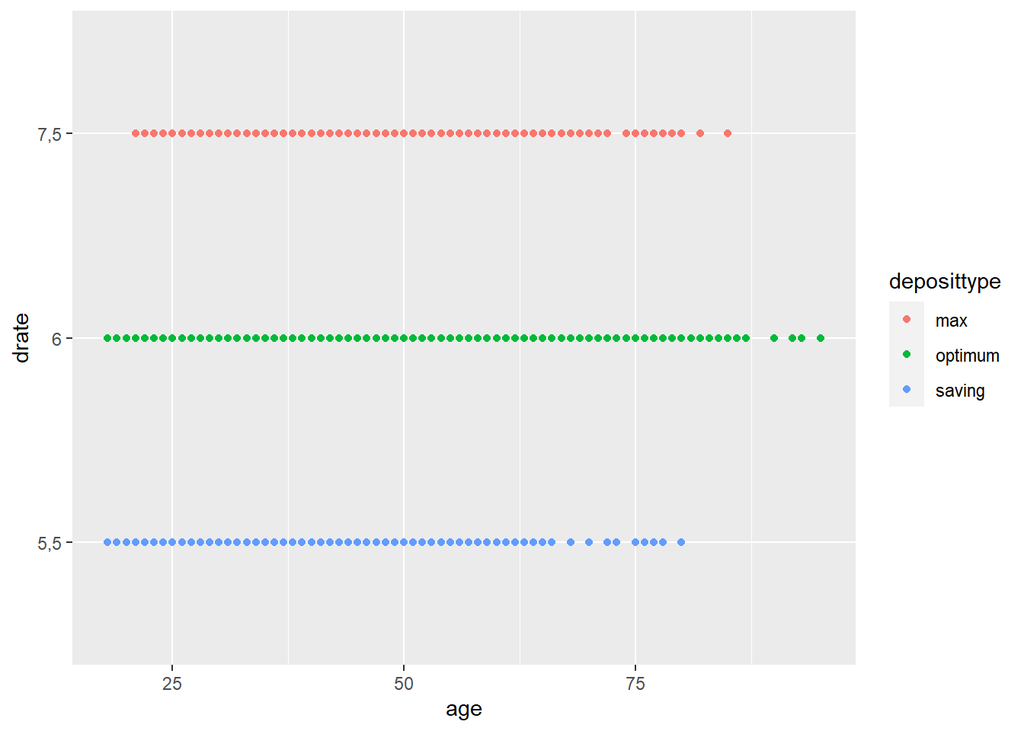

```r
ggplot(data = itog, mapping = aes(x = age, y = drate, color = deposittype)) + geom_point()
```

## Корреляция между длительностью общения и возрастом

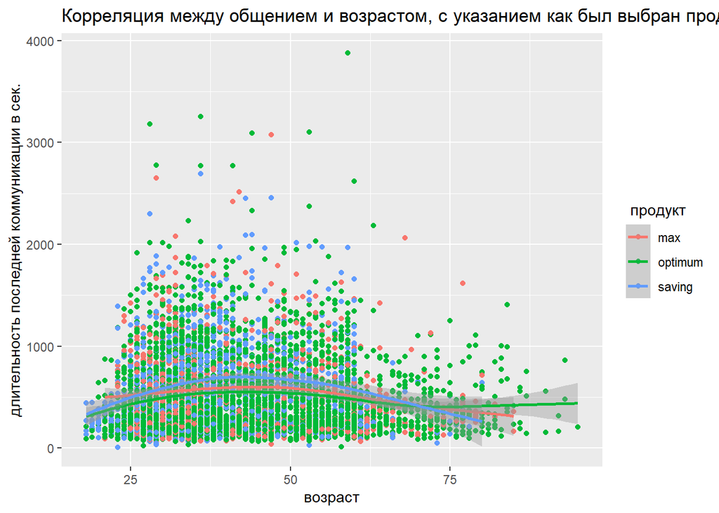

```r
ggplot(data = itog, mapping = aes(x = age, y = duration.x, color = deposittype)) + geom_point() +geom_smooth() + labs(x = "возраст", y = "длительность последней коммуникации в сек.", color =' продукт') + ggtitle("Корреляция между общением и возрастом, с указанием как был выбран продукт")
```

## Зависимость продукта от баланса

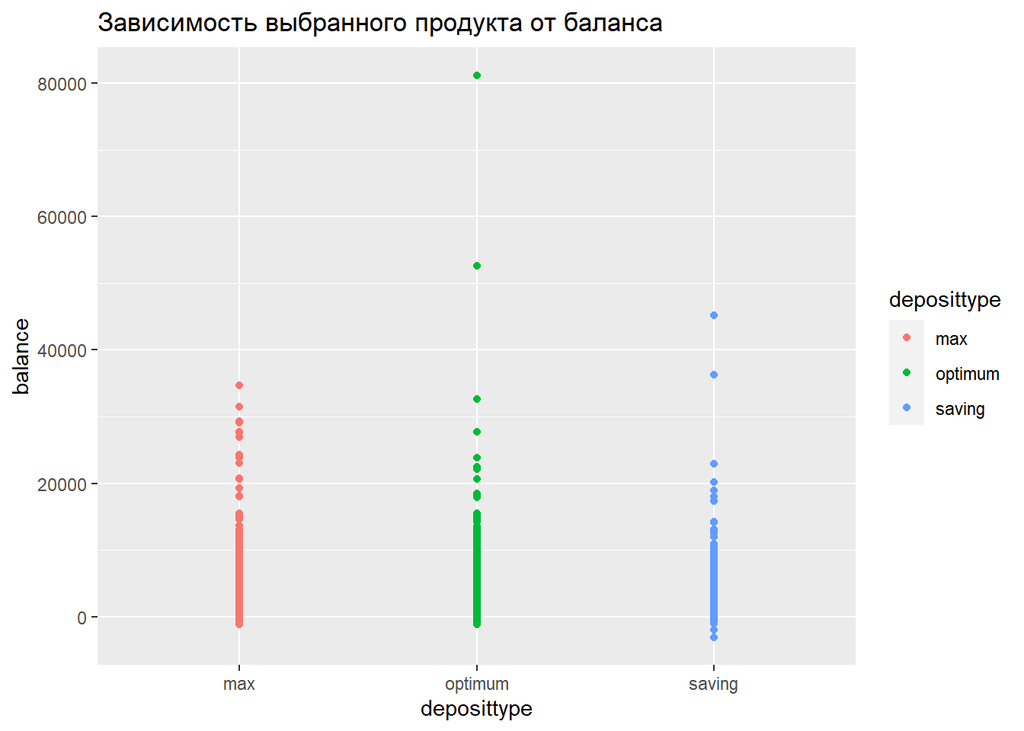

```r
ggplot(itog) + geom_point(mapping = aes(x = deposittype, y = balance, color = deposittype)) + ggtitle("Зависимость выбранного продукта от баланса")
```

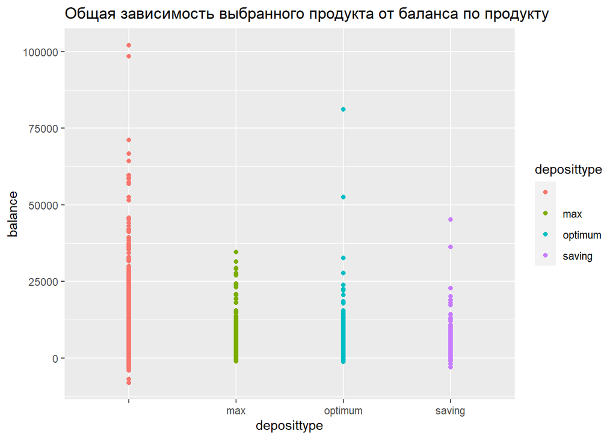

```r
ggplot(itog_ob) + geom_point(mapping = aes(x = deposittype, y = balance, color = deposittype)) + ggtitle("Общая зависимость выбранного продукта от баланса по продукту")
```

## Зависимости количество контакта от выбранного продукта

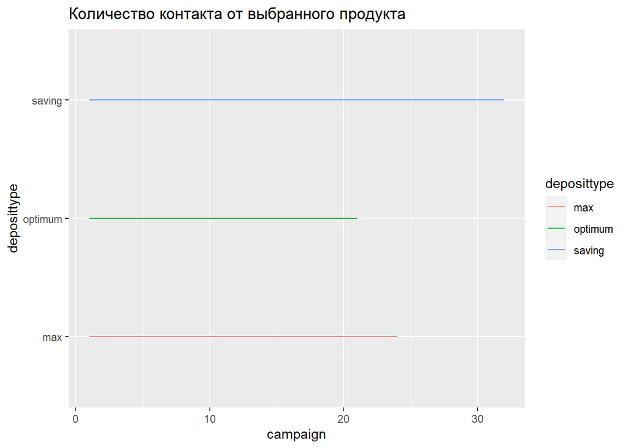

```r
ggplot(itog) + geom_line(mapping = aes(y = deposittype, x = campaign, color = deposittype)) + ggtitle("Количество контакта от выбранного продукта")
```

## Зависимости количество выбранных продуктов от клиентов с которыми ранее не было общения

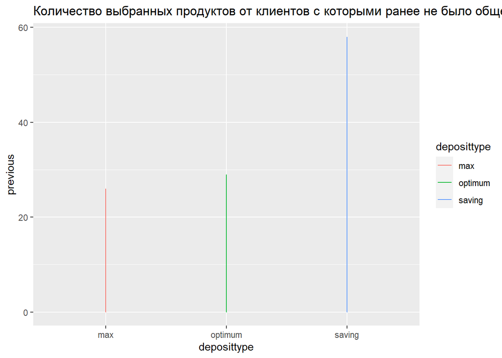

```r
ggplot(itog) + geom_line(mapping = aes(x = deposittype, y = previous, color = deposittype)) + ggtitle("Количество выбранных продуктов от клиентов с которыми ранее не было общения")
```

## Построим гистограмму распределения клиентов по возрасту

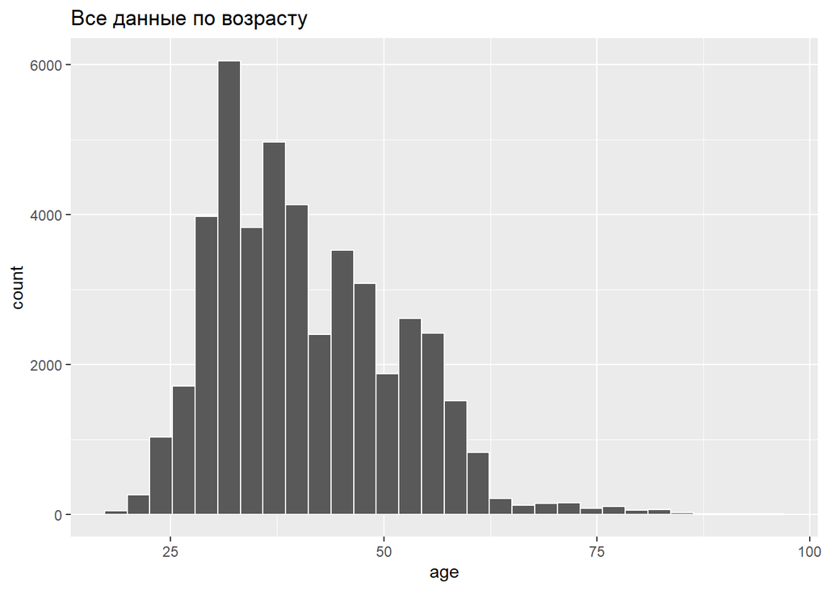

```r
ggplot(itog_ob, mapping = aes(x = age)) + geom_histogram(color = "white") + ggtitle("Все данные по возрасту")
```

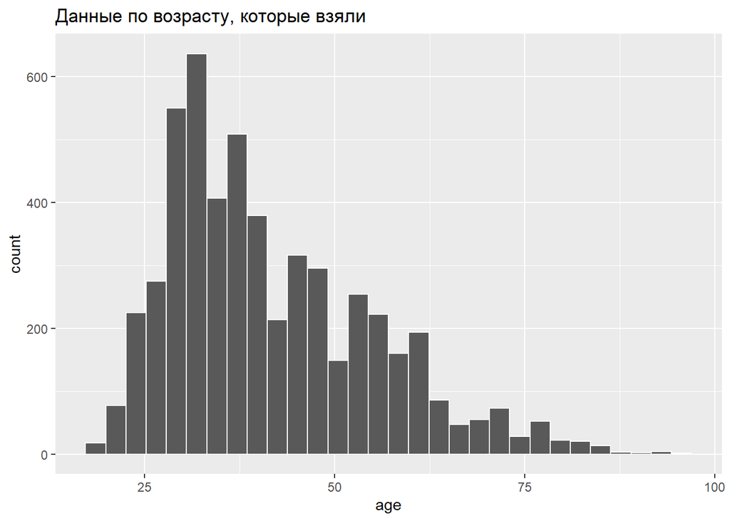

```r
ggplot(itog, mapping = aes(x = age)) + geom_histogram(color = "white") + ggtitle("Данные по возрасту, которые взяли")
```

## Построим гистограмму распределения длительности последней коммуникации в секундах

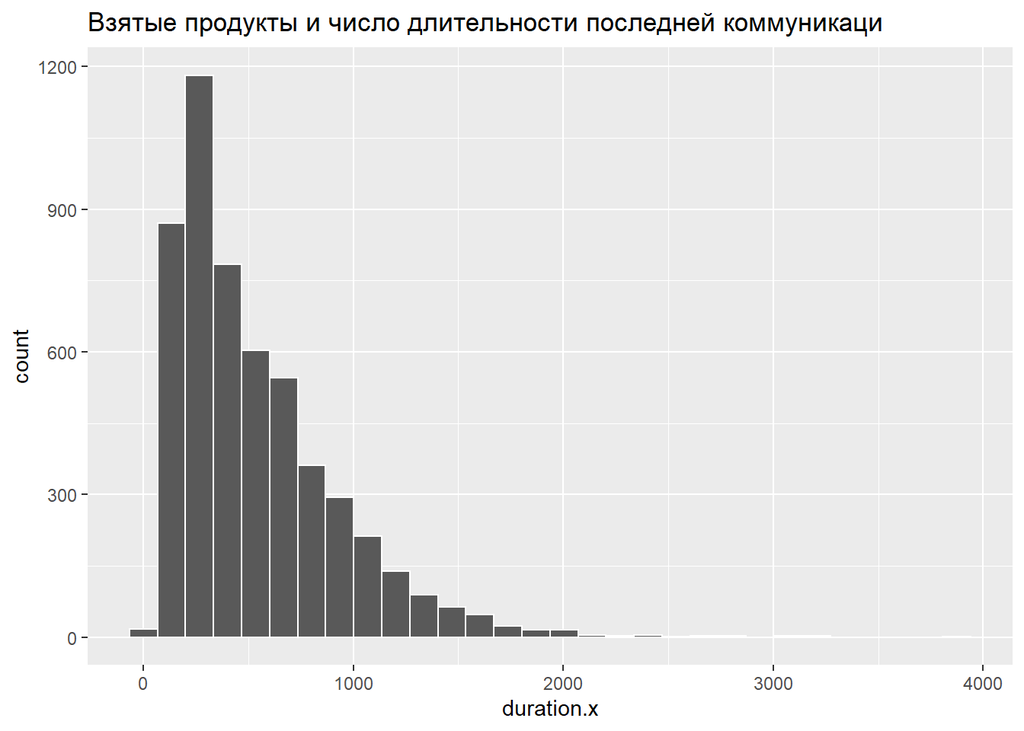

```r
ggplot(itog, mapping = aes(x = duration.x)) + geom_histogram(color = "white") + ggtitle("Взятые продукты и число длительности последней коммуникаци")
```

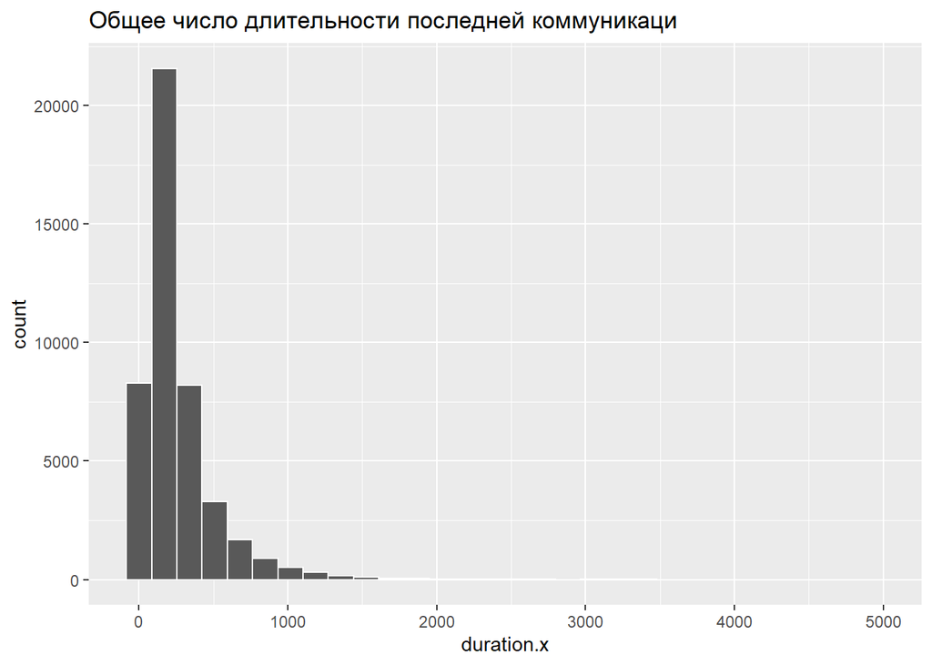

```r
ggplot(itog_ob, mapping = aes(x = duration.x)) + geom_histogram(color = "white") + ggtitle("Общее число длительности последней коммуникаци")
```

## Построим гистограмму распределения когда в месяце была последняя коммуникация

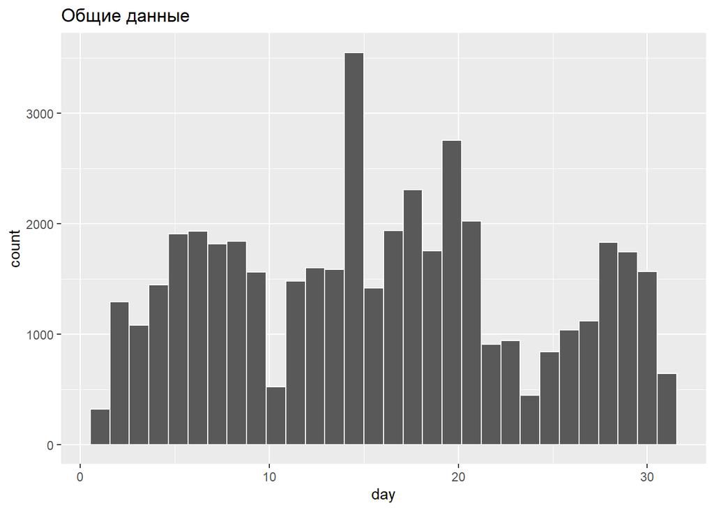

```r
ggplot(itog_ob, mapping = aes(x = day)) + geom_histogram(color = "white") + ggtitle("Общие данные")
```

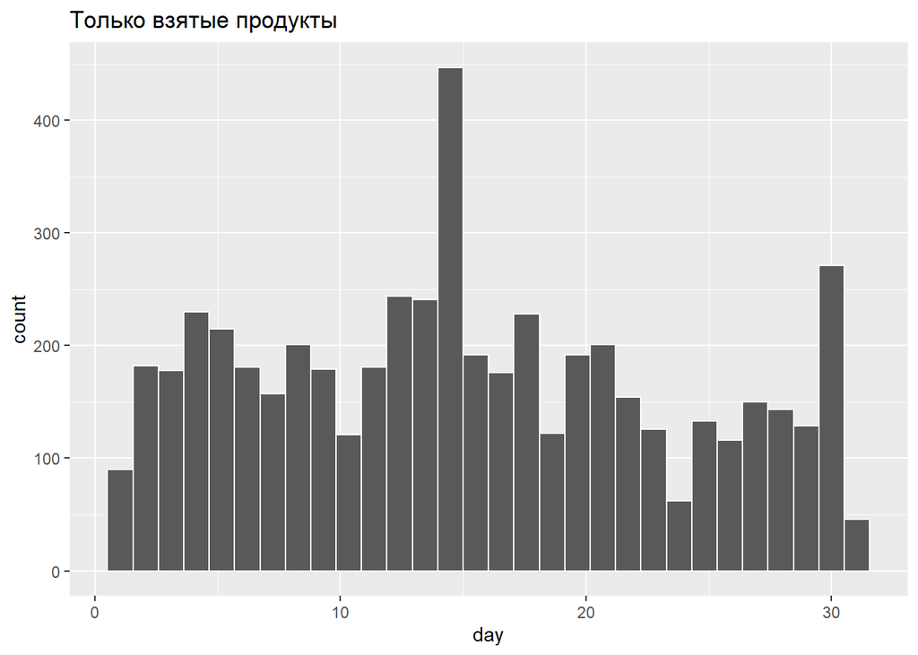

```r
ggplot(itog, mapping = aes(x = day)) + geom_histogram(color = "white") + ggtitle("Только взятые продукты")
```

# Посмотрим как у нас влияет маркетинг на взятые продукты

## Посмотрим на количество контактов с клиентом в рамках данной рекламной кампании

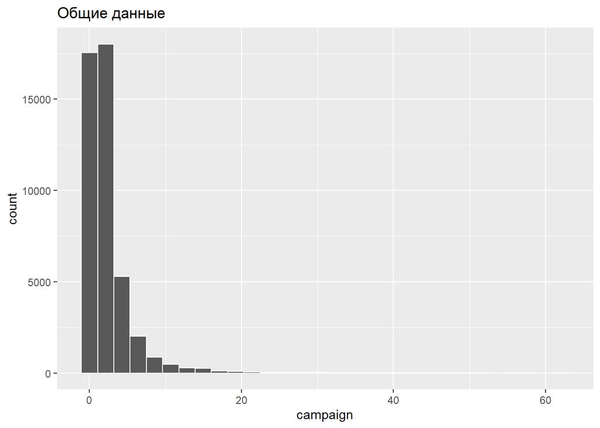

```r
ggplot(itog_ob, mapping = aes(x = campaign)) + geom_histogram(color = "white") + ggtitle("Общие данные")
```

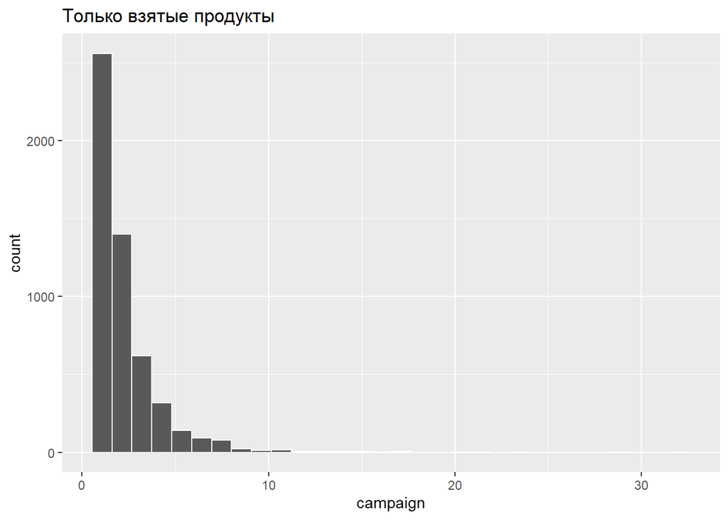

```r
ggplot(itog, mapping = aes(x = campaign)) + geom_histogram(color = "white") + ggtitle("Только взятые продукты")
```

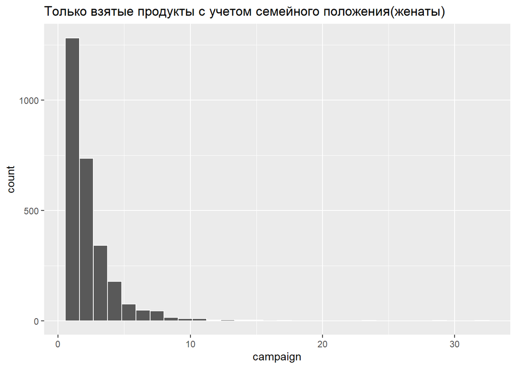

```r
ggplot(filter(itog, marital %in% c("married")), mapping = aes(x = campaign)) + geom_histogram(color = "white") + ggtitle("Только взятые продукты с учетом семейного положения(женаты)")
```

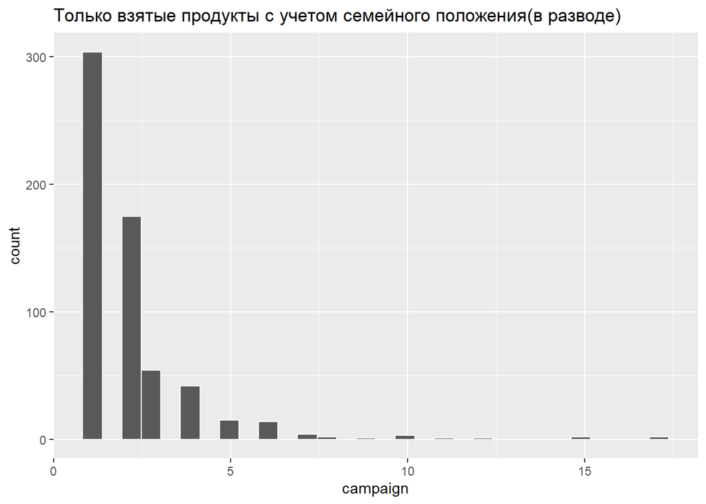

```r
ggplot(filter(itog, marital %in% c("divorced")), mapping = aes(x = campaign)) + geom_histogram(color = "white") + ggtitle("Только взятые продукты с учетом семейного положения(в разводе)")
```

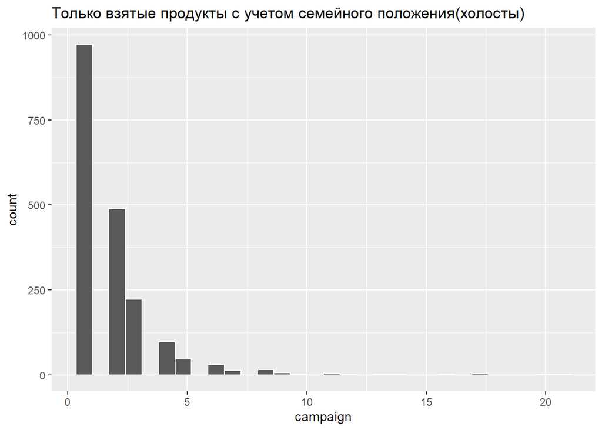

```r
ggplot(filter(itog, marital %in% c("single")), mapping = aes(x = campaign)) + geom_histogram(color = "white") + ggtitle("Только взятые продукты с учетом семейного положения(холосты)")
```

##Количество контактов в среднем

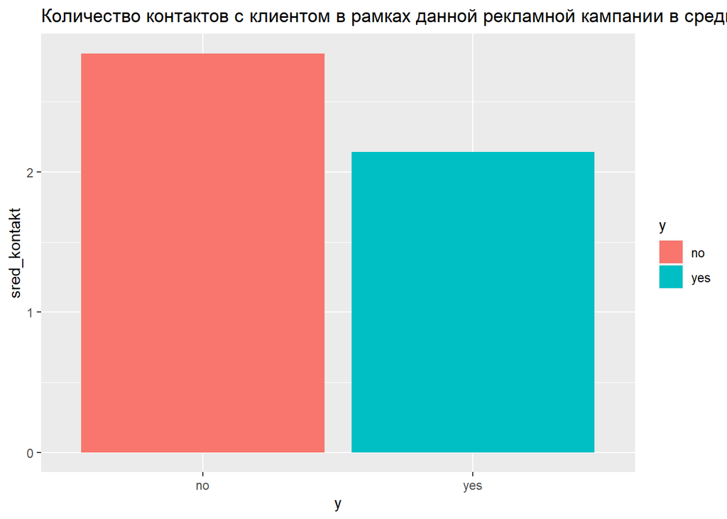

```r
ggplot(itog_ob %>% group_by(y) %>% summarise(sred_kontakt = mean(campaign))) + geom_col(mapping = aes(x = y, y = sred_kontakt, fill = y)) + ggtitle("Количество контактов с клиентом в рамках данной рекламной кампании в среднем")
```

## Как видно берут продукт после 2 связи с клиентом

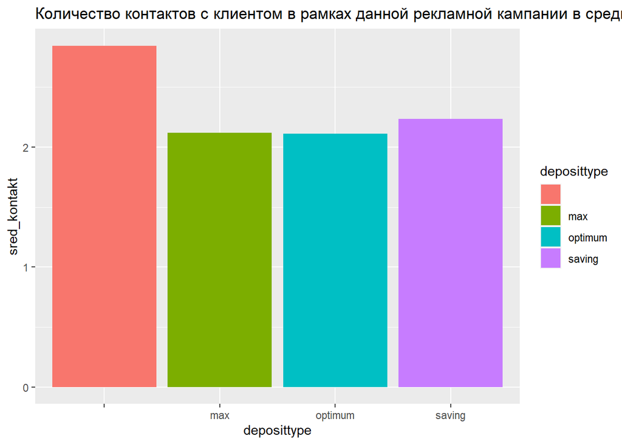

```r
ggplot(itog_ob %>% group_by(deposittype) %>% summarise(sred_kontakt = mean(campaign))) + geom_col(mapping = aes(x = deposittype, y = sred_kontakt, fill = deposittype)) + ggtitle("Количество контактов с клиентом в рамках данной рекламной кампании в среднем по продуктам")
```

```r
kontakt <- itog_ob %>% group_by(deposittype) %>% summarise(sred_kontakt = mean(campaign))

kontakt
```

```
## # A tibble: 4 x 2
##   deposittype sred_kontakt
##   <chr>              <dbl>
## 1 ""                  2.85
## 2 "max"               2.12
## 3 "optimum"           2.11
## 4 "saving"            2.23
```

## Количество успешных контактов

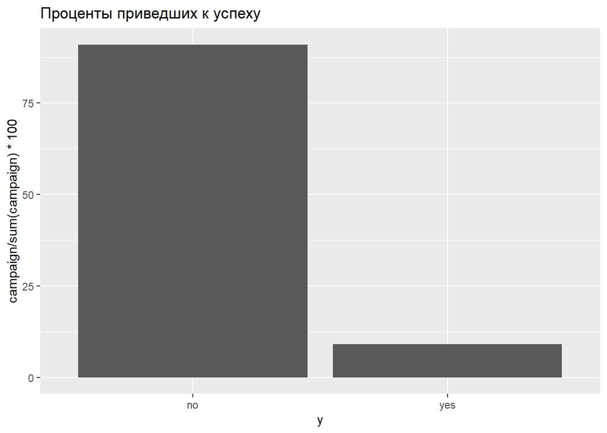

```r
ggplot(itog_ob) + geom_col(mapping = aes(x = y, y = campaign/sum(campaign) * 100)) + ggtitle("Проценты приведших к успеху")
```

```r
uspeh <- itog_ob %>% group_by(y) %>% summarise(uspeh_proc = sum(campaign))
uspeh
```

```
## # A tibble: 2 x 2
##   y     uspeh_proc
##   <chr>      <int>
## 1 no        113618
## 2 yes        11322
```

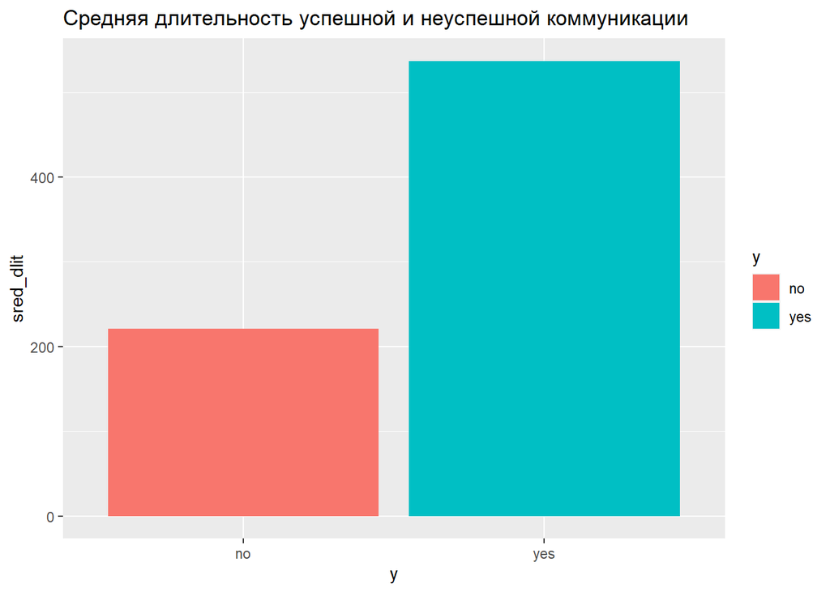

```r
ggplot(itog_ob %>% group_by(y) %>% summarise(sred_dlit = mean(duration.x))) + geom_col(mapping = aes(x = y, y = sred_dlit, fill = y)) + ggtitle("Средняя длительность успешной и неуспешной коммуникации")
```

## Чем дольше идет ообщение, тем больше вероятность того, что будет взят продукт

## число дней с прошлой коммуникации

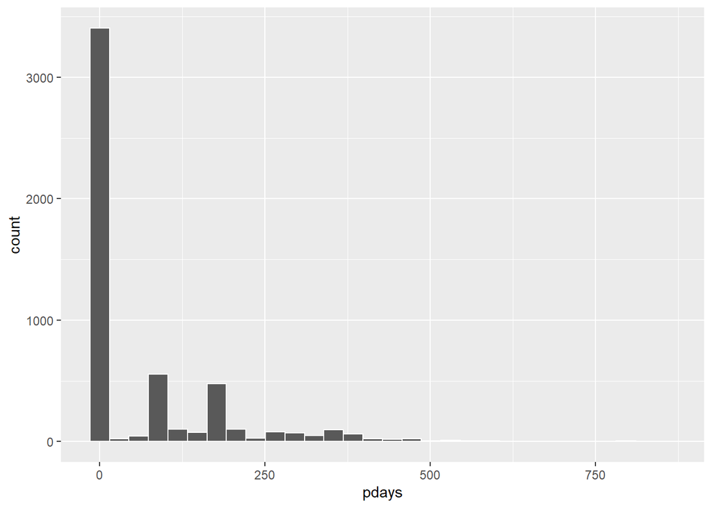

```r
ggplot(itog, mapping = aes(x = pdays)) + geom_histogram(color = "white")
```

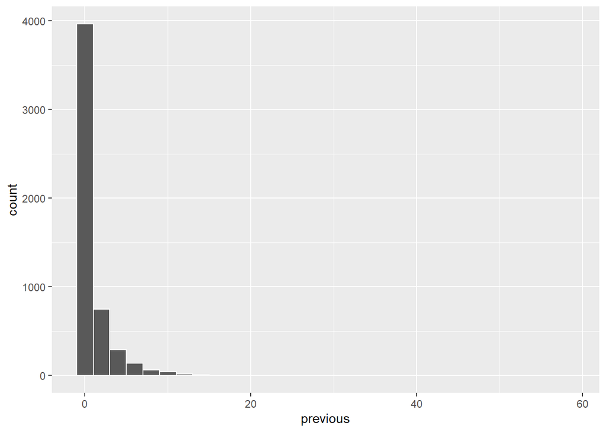

```r
ggplot(itog, mapping = aes(x = previous)) + geom_histogram(color = "white")
```

## большое количесто -1, что означает, что ранее с клиентом не связывалис

## Портрет клиента

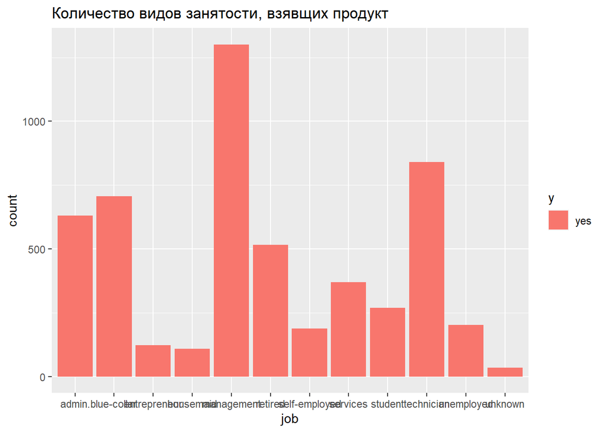

```r
ggplot(itog) + geom_bar(mapping = aes(x = job, fill=y), position = 'dodge') + ggtitle("Количество видов занятости, взявщих продукт")
```

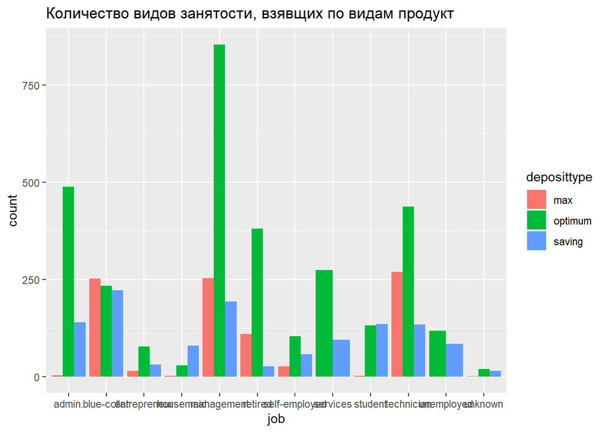

```r
ggplot(itog) + geom_bar(mapping = aes(x = job, fill=deposittype), position = 'dodge') + ggtitle("Количество видов занятости, взявщих по видам продукт")
```

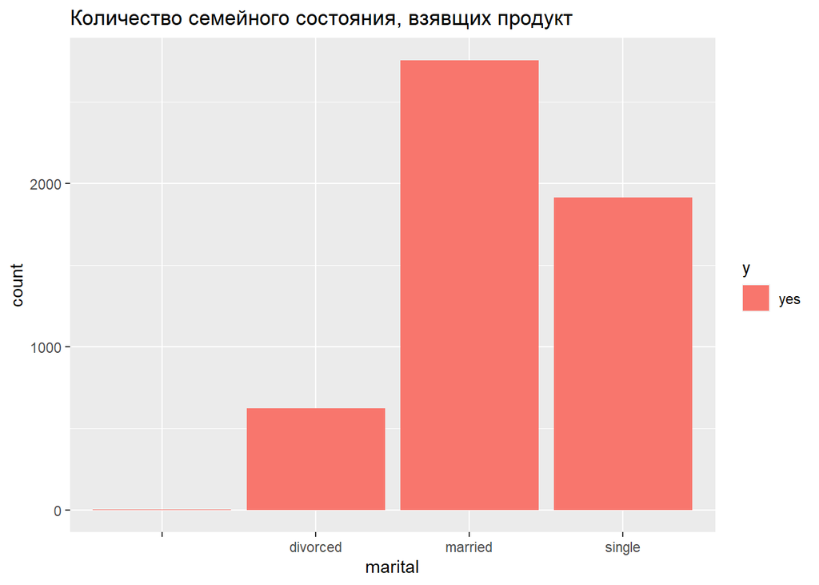

```r
ggplot(itog) + geom_bar(mapping = aes(x = marital, fill=y), position = 'dodge') + ggtitle("Количество семейного состояния, взявщих продукт")
```

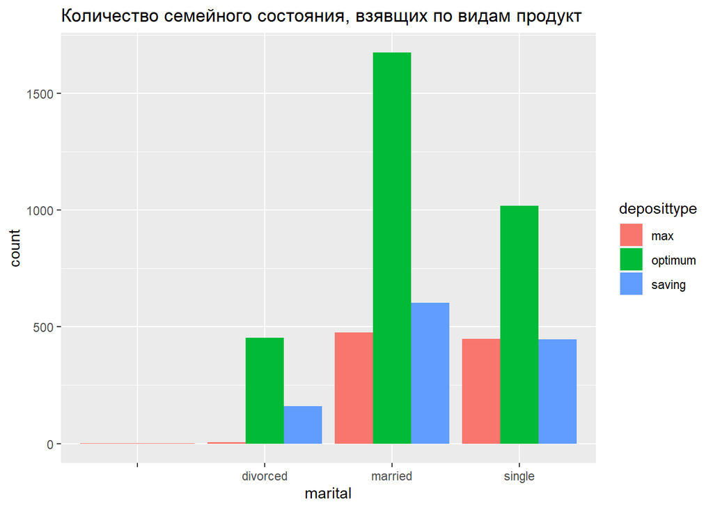

```r
ggplot(itog) + geom_bar(mapping = aes(x = marital, fill=deposittype), position = 'dodge') + ggtitle("Количество семейного состояния, взявщих по видам продукт")
```

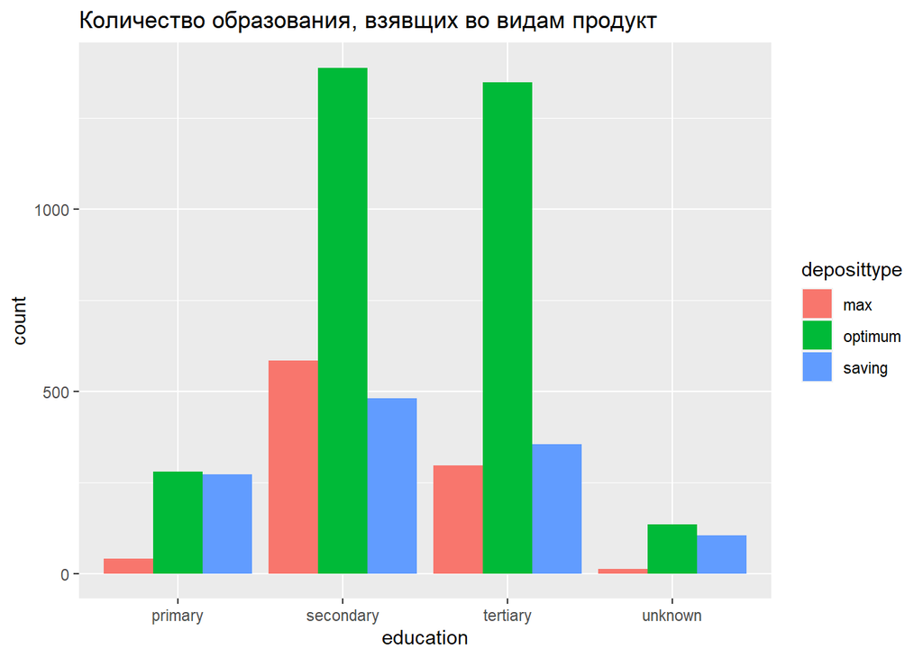

```r
ggplot(itog) + geom_bar(mapping = aes(x = education, fill=deposittype), position = 'dodge') + ggtitle("Количество образования, взявщих во видам продукт")
```